# Análise Estatística de Biossegurança em Propriedades de Aquicultura

Avaliação da Conformidade em Práticas de Manejo e Prevenção

Carlos Antônio Zarzar

08 de agosto de 2025

# 1 Resumo Executivo

Este relatório apresenta uma análise estatística abrangente dos dados de conformidade em biossegurança coletados em cinco propriedades de aquicultura. O questionário avaliou quatro dimensões críticas: **Avaliação de Riscos (G1)**, **Equipamentos e Veículos (G2)**, **Qualidade da Água (G3)** e **Gerenciamento de Riscos (G4)**.

## 1.1 Principais Achados

- **Conformidade Geral:** 69.6% das respostas foram positivas
- **Melhor Grupo:** G3 - Qualidade da Água (80.0%)
- **Pior Grupo:** G1 - Avaliação de Riscos (64.0%)
- **Melhor Propriedade:** Propriedade A (79.1%)
- **Pior Propriedade:** Propriedade B (48.8%)
- **Variabilidade entre propriedades:** 12.7% (desvio padrão)

A análise revelou diferenças significativas entre as propriedades (p < 0.001), mas não entre os grupos de perguntas (p = 0.586), indicando que o desempenho varia mais entre proprietários do que entre categorias de práticas.

# 2 Metodologia

## 2.1 Coleta de Dados

Os dados foram coletados através de questionário estruturado aplicado em cinco propriedades de aquicultura (denominadas A, B, C, D e E), abrangendo quatro grupos temáticos:

- **G1 - Avaliação de Riscos (25 perguntas):** Controle sanitário, quarentena, protocolos de entrada de animais
- **G2 - Equipamentos e Veículos (13 perguntas):** Manutenção de equipamentos, controle de acesso, biossegurança
- **G3 - Qualidade da Água (13 perguntas):** Monitoramento, tratamento e controle da qualidade da água
- **G4 - Gerenciamento de Riscos (35 perguntas):** Manejo, alimentação, controle de pragas e mortalidade

## 2.2 Análise Estatística

As análises incluíram:

- **Estatísticas descritivas:** frequências, percentuais e medidas de tendência central
- **Análises comparativas:** comparação entre grupos e propriedades
- **Testes de independência:** Qui-quadrado para avaliar associações
- **ANOVA:** comparação de médias entre grupos
- **Identificação de padrões críticos:** perguntas e propriedades com baixa conformidade

```
## Estrutura dos dados:
```

```
## Total de observações: 430
```

```
## Número de entrevistados: 5
```

```
## Número de grupos: 4
```

```
## Total de perguntas: G1=25, G2=13, G3=13, G4=35
```

```
##
## Distribuição de respostas:
```

```
## Sim: 298 (69.3%)
```

```
## Não: 130 (30.2%)
```

```
## NA: 2 (0.5%)
```

# 3 Análise Descritiva Geral

## 3.1 Distribuição Global das Respostas

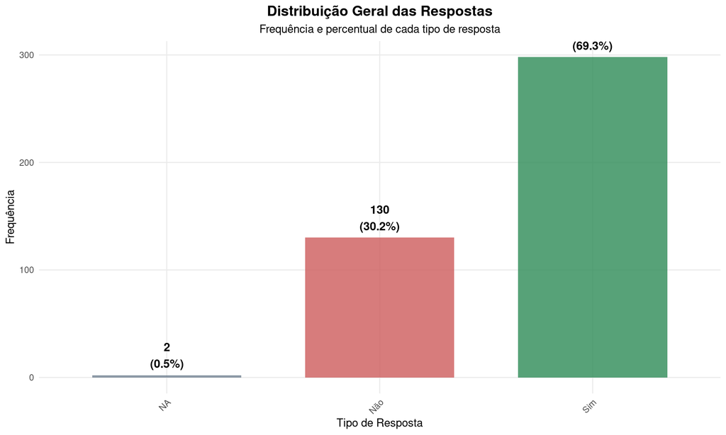

Distribuição geral das respostas no questionário

**Interpretação:** A distribuição geral das respostas mostra que aproximadamente 70% das práticas avaliadas estão sendo implementadas adequadamente pelas propriedades. A baixa incidência de respostas “NA” (0.5%) indica que a maioria das práticas são aplicáveis ao contexto das propriedades estudadas.

## 3.2 Perguntas por Grupo

Distribuição de perguntas por grupo temático

| Grupo | Perguntas | Percentual |
| --- | --- | --- |
| G1 - Avaliação de Riscos | 25 | 29.1% |
| G2 - Equipamentos e Veículos | 13 | 15.1% |
| G3 - Qualidade da Água | 13 | 15.1% |
| G4 - Gerenciamento de Riscos | 35 | 40.7% |

# 4 Análise por Grupos Temáticos

## 4.1 Conformidade por Grupo

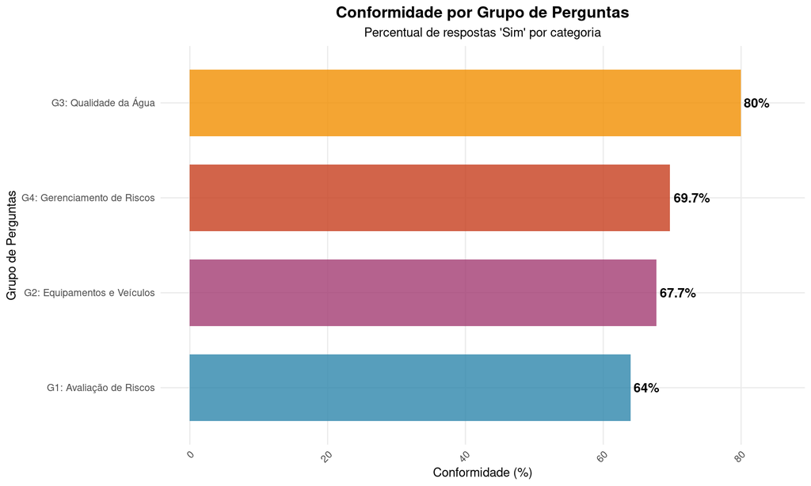

Conformidade por grupo de perguntas

**Análise dos Resultados por Grupo:**

### 4.1.1 G3 - Qualidade da Água (80.0%)

Este grupo apresentou a melhor performance, com 52 respostas positivas de 65 total. O resultado indica que as propriedades têm bom controle sobre parâmetros físico-químicos da água e implementam medidas adequadas de monitoramento.

*Pontos fortes identificados:* Monitoramento regular de parâmetros, uso de filtros e telas *Áreas de melhoria:* Métodos de desinfecção da água

### 4.1.2 G4 - Gerenciamento de Riscos (69.7%)

Com 122 respostas positivas de 175 total, este grupo mostra conformidade satisfatória nas práticas operacionais, incluindo manejo, alimentação e controle de mortalidade.

*Pontos fortes identificados:* Controle de mortalidade, uso de EPIs, manutenção de equipamentos *Áreas de melhoria:* Controle de pragas e vetores, programas de vacinação

### 4.1.3 G2 - Equipamentos e Veículos (67.7%)

Com 44 respostas positivas de 65 total, este grupo apresenta oportunidades de melhoria em aspectos de biossegurança relacionados a equipamentos e controle de acesso.

*Pontos fortes identificados:* Manutenção de equipamentos, produtos registrados *Áreas de melhoria:* Controle de visitantes, monitoramento de tráfego

### 4.1.4 G1 - Avaliação de Riscos (64.0%)

O grupo com menor conformidade (80 de 125 respostas positivas) indica necessidade de melhorias significativas em protocolos sanitários e de quarentena.

*Pontos fortes identificados:* Acompanhamento veterinário, monitoramento de doenças *Áreas de melhoria:* Protocolos de quarentena, controle de movimentação, desinfecção de veículos

Detalhamento da conformidade por grupo temático

| Grupo | Conformidade (%) | Respostas Sim | Respostas Não | Respostas NA |
| --- | --- | --- | --- | --- |
| G1 - Avaliação de Riscos | 64.0 | 80 | 45 | 0 |
| G2 - Equipamentos e Veículos | 67.7 | 44 | 21 | 0 |
| G3 - Qualidade da Água | 80.0 | 52 | 13 | 0 |
| G4 - Gerenciamento de Riscos | 69.7 | 122 | 51 | 2 |

# 5 Análise por Propriedades

## 5.1 Ranking de Conformidade

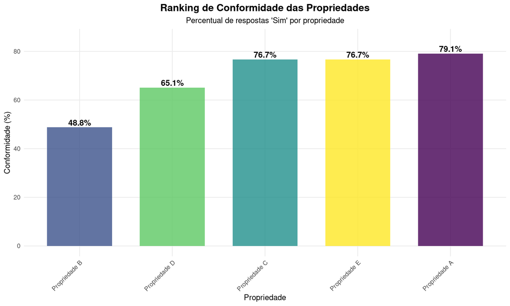

Ranking de conformidade das propriedades

**Análise Individual das Propriedades:**

### 5.1.1 Propriedade A (79.1%)

A propriedade com melhor desempenho geral, com 68 respostas positivas de 86 total.

**Pontos fortes:** Melhor grupo - G3 (92.3%), bom controle de qualidade da água **Pontos fracos:** Pior grupo - G2 (69.2%), controle de equipamentos e veículos **Recomendações:** Aprimorar protocolos de controle de acesso e monitoramento de visitantes

### 5.1.2 Propriedade C (76.7%)

Segunda colocada no ranking, com 66 respostas positivas de 86 total.

**Pontos fortes:** Melhor grupo - G2 (100%), excelente controle de equipamentos **Pontos fracos:** Pior grupo - G3 (53.8%), qualidade da água **Recomendações:** Implementar monitoramento mais rigoroso de parâmetros da água

### 5.1.3 Propriedade E (76.7%)

Empatada em segundo lugar, com 66 respostas positivas de 86 total.

**Pontos fortes:** Melhor grupo - G3 (92.3%), boa qualidade da água **Pontos fracos:** Pior grupo - G2 (69.2%), equipamentos e veículos **Recomendações:** Melhorar controle de acesso e biossegurança de equipamentos

### 5.1.4 Propriedade D (65.1%)

Quarta posição com 56 respostas positivas de 86 total.

**Pontos fortes:** Melhor grupo - G3 (100%), excelente qualidade da água **Pontos fracos:** Pior grupo - G2 (46.2%), equipamentos e veículos **Recomendações:** Focar em melhorias significativas no controle de equipamentos e acesso

### 5.1.5 Propriedade B (48.8%)

Necessita melhorias urgentes, com apenas 42 respostas positivas de 86 total.

**Pontos fortes:** Melhor grupo - G3 (61.5%), relativo controle da água **Pontos fracos:** Pior grupo - G1 (40.0%), avaliação de riscos **Recomendações:** Implementação urgente de protocolos de biossegurança e controle sanitário

Ranking de conformidade das propriedades

| Posição | Propriedade | Conformidade (%) | Melhor Grupo | Pior Grupo |
| --- | --- | --- | --- | --- |
| 1 | Propriedade A | 79.1 | G3 | G2 |
| 2 | Propriedade C | 76.7 | G2 | G3 |
| 3 | Propriedade E | 76.7 | G3 | G2 |
| 4 | Propriedade D | 65.1 | G3 | G2 |
| 5 | Propriedade B | 48.8 | G3 | G1 |

# 6 Análise Cruzada: Propriedades vs Grupos

## 6.1 Mapa de Calor da Conformidade

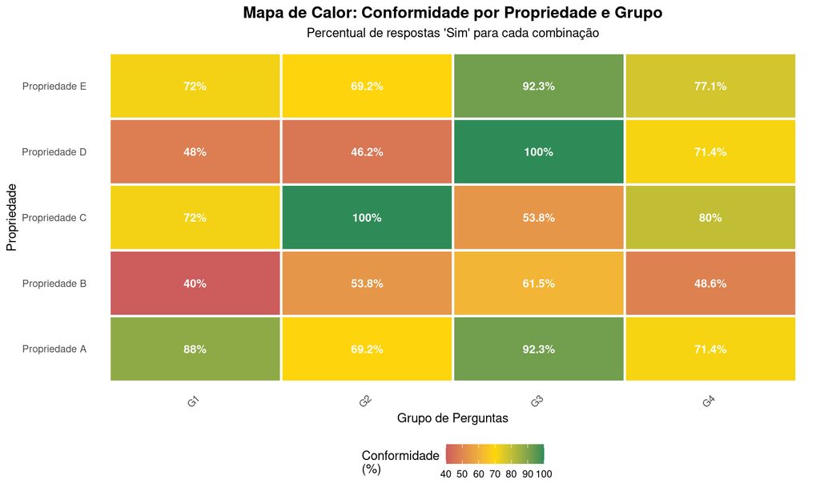

Mapa de calor: conformidade por propriedade e grupo

## 6.2 Perfis de Conformidade

**Interpretação dos Perfis:**

- **Propriedades com perfil consistente:** Propriedade A (variação de 23.1%) e Propriedade E (variação de 23.1%)
- **Propriedades com alta variabilidade:** Propriedade C (variação de 46.2%) e Propriedade D (variação de 53.9%)
- **Padrões identificados:** G3 (Qualidade da Água) é consistentemente o melhor grupo para 4 das 5 propriedades

Conformidade por propriedade e grupo (%)

| Propriedade | G1 | G2 | G3 | G4 |
| --- | --- | --- | --- | --- |
| Propriedade A | 88.0% | 69.2% | 92.3% | 71.4% |
| Propriedade B | 40.0% | 53.8% | 61.5% | 48.6% |
| Propriedade C | 72.0% | 100.0% | 53.8% | 80.0% |
| Propriedade D | 48.0% | 46.2% | 100.0% | 71.4% |
| Propriedade E | 72.0% | 69.2% | 92.3% | 77.1% |

# 7 Análises Estatísticas

## 7.1 Testes de Independência

### 7.1.1 Teste Qui-quadrado: Grupos vs Respostas

```
## Teste Qui-quadrado - Grupos vs Respostas:
```

```
## χ² = 5.359, gl = 3, p-valor = 0.147
```

```
##
## Interpretação: Não há evidência estatística de associação entre os grupos
```

```
## de perguntas e as respostas obtidas (p > 0.05).
```

**Interpretação:** O teste qui-quadrado de independência entre grupos de perguntas e respostas não mostrou associação significativa (p = 0.147). Isso indica que a proporção de respostas positivas é estatisticamente similar entre os diferentes grupos temáticos.

### 7.1.2 Teste Qui-quadrado: Propriedades vs Respostas

```
## Teste Qui-quadrado - Propriedades vs Respostas:
```

```
## χ² = 26.411, gl = 4, p-valor = 2.614e-05
```

```
##
## Interpretação: Há evidência estatística significativa de associação
```

```
## entre as propriedades e as respostas obtidas (p < 0.001).
```

**Interpretação:** O teste qui-quadrado demonstrou associação altamente significativa entre propriedades e respostas (p < 0.001). Isso confirma que existe diferença real no padrão de conformidade entre as propriedades estudadas.

## 7.2 ANOVA: Comparação entre Grupos

```
## ANOVA - Diferenças entre grupos:
```

```
## F = 0.665, gl = 3, p-valor = 0.586
```

```
##
## Interpretação: Não há diferença estatisticamente significativa
```

```
## na conformidade média entre os grupos de perguntas.
```

**Interpretação:** A ANOVA confirmou que não há diferenças significativas na conformidade média entre os grupos (p = 0.586), corroborando os resultados do teste qui-quadrado.

# 8 Identificação de Pontos Críticos

## 8.1 Perguntas com Baixa Conformidade

A análise identificou 38 perguntas com taxa problemática ≥40%, incluindo 5 perguntas com 100% de não conformidade:

Perguntas com maior taxa de não conformidade

[output not shown]

## 8.2 Propriedades com Baixa Conformidade Geral

```
## Propriedades com conformidade <70%:
```

```
## - Propriedade B: 48.8%
```

```
## - Propriedade D: 65.1%
```

```
##
## Estas propriedades necessitam intervenção prioritária.
```

# 9 Variabilidade e Consistência

## 9.1 Análise de Variabilidade

**Interpretação da Variabilidade:**

A variabilidade moderada (12.7%) indica que, embora existam diferenças entre propriedades, elas não são extremamente heterogêneas, sugerindo potencial para padronização de práticas.

# 10 Recomendações e Plano de Ação

## 10.1 Recomendações Gerais

Com base nos resultados da análise, as seguintes recomendações são propostas:

### 10.1.1 Curto Prazo (0-6 meses)

1. **Prioridade Alta - Propriedade B:** Implementação urgente de protocolos básicos de biossegurança, especialmente em avaliação de riscos (G1)
2. **Prioridade Alta - Controle de Pragas:** Estabelecer programa de controle de pragas com registro adequado
3. **Prioridade Média - Padronização:** Desenvolver POPs baseados nas melhores práticas identificadas

### 10.1.2 Médio Prazo (6-18 meses)

1. **Capacitação técnica:** Treinamento focado nos grupos com menor conformidade (G1 e G2)
2. **Sistema de monitoramento:** Implementar sistema de acompanhamento contínuo das práticas
3. **Compartilhamento de conhecimento:** Promover intercâmbio entre propriedades de melhor e pior desempenho

### 10.1.3 Longo Prazo (18+ meses)

1. **Certificação:** Desenvolver sistema de certificação em biossegurança
2. **Auditoria externa:** Implementar auditorias periódicas independentes

## 10.2 Plano de Monitoramento

- **Frequência de avaliação:** Semestral para propriedades críticas, anual para demais
- **Indicadores-chave:** Taxa de conformidade geral, conformidade por grupo, variabilidade entre propriedades
- **Responsáveis:** Técnicos especializados em aquicultura e biossegurança
- **Metas de melhoria:** Alcançar conformidade mínima de 75% em todas as propriedades em 18 meses

# 11 Conclusões

## 11.1 Principais Achados

1. **Conformidade Geral:** A análise revelou uma conformidade geral de 69.6%, indicando nível moderado de implementação das práticas de biossegurança
2. **Desempenho por Grupos:** O grupo G3 (Qualidade da Água) apresentou melhor desempenho (80%), enquanto G1 (Avaliação de Riscos) mostrou maior necessidade de melhorias (64%)
3. **Variabilidade entre Propriedades:** Diferenças significativas foram identificadas, com variação de 30.3 pontos percentuais entre a melhor (79.1%) e pior (48.8%) propriedade
4. **Pontos Críticos Identificados:** 38 perguntas apresentaram taxa problemática ≥40%, com 5 perguntas sem implementação em nenhuma propriedade

## 11.2 Implicações para o Setor

Os resultados desta análise têm implicações importantes para:

- **Gestão de riscos:** Necessidade de protocolos mais rigorosos de avaliação e controle de riscos sanitários
- **Políticas de biossegurança:** Desenvolvimento de diretrizes específicas para aquicultura brasileira
- **Capacitação técnica:** Programas de treinamento focados em áreas deficitárias
- **Regulamentação setorial:** Base técnica para elaboração de normas mais específicas

## 11.3 Limitações do Estudo

- Amostra limitada a cinco propriedades de uma região específica
- Possível viés de resposta devido à natureza autodeclaratória do questionário
- Ausência de validação in loco das práticas relatadas
- Sugestões para estudos futuros: ampliação da amostra, validação por observação direta, análise temporal